# Season report: 4545 Season 14

[figure not shown]

### Overview

- The [season](https://www.lichess4545.com/team4545/season/14/summary/) was played from 17 September 2018 to 11 November 2018.
- 230 players took part, playing 639 games in total. The season’s forfeit rate was 11.2 per cent.[^1]
- White won 282 games (44.2%), 95 games (14.9%) were drawn, and Black won 241 games (37.8%).[^2]
- 423 games ended with a resignation, 108 games by checkmate, 8 games by time running out, and 3 games by stalemate.

[figure not shown]

1st place

[Hey Guys, it’s John](https://www.lichess4545.com/team4545/season/14/team/28/)

2nd place

[Ha, We Got Lovlas](https://www.lichess4545.com/team4545/season/14/team/22/)

3rd place

[Six Piece Tablebase](https://www.lichess4545.com/team4545/season/14/team/11/)

| Gold | Silver | Bronze |
| --- | --- | --- |
| colwem (8) | atil4 (8) | Footpath (8) |
| TCGRIF (8) | Axp156 (8) | k-night-moves (8) |
| ErinYu (7) | Delpire (8) | FilP (7) |
| PP_92 (7) | Forhavu (7) | mekumcu (7) |
| JoeyMellberg (6) | lovlas (7) | Chaskar (5) |
| toni4127 (6) | RookTown (5) | redban (4) |
| GogoYubari (1) | didomova (2) | Alegre_River (2) |
| michaeltallovsky (1) | Thanmarkou (1) | david252525 (1) |
| py3 (1) |  | mn8 (1) |
| y3LL3r (1) |  | MoistvonLipwig (1) |

#### Story of the season

[figure not shown]

#### Top of the boards

The top player performances by board (minimum 4 games played).[^3]

| Board | Player | Games | Points | Board Perf. |
| --- | --- | --- | --- | --- |
| 1 | ihideonbush | 6 | 6 | 2893.83333333333 |
| 1 | mn8 | 7 | 6.5 | 2611.42857142857 |
| 1 | Assassin_in_White | 7 | 5.5 | 2398.71428571429 |
| 1 | Scrooge | 6 | 4.5 | 2395.16666666667 |
| 1 | lovlas | 7 | 5.5 | 2389.57142857143 |
| 2 | PublicRadio | 5 | 5 | 2759.8 |
| 2 | Chaskar | 5 | 4.5 | 2301 |
| 2 | PP_92 | 7 | 5.5 | 2208.14285714286 |
| 2 | kevban | 6 | 4.5 | 2135.16666666667 |
| 2 | nondrama | 7 | 5 | 2113.28571428571 |

[output cut: 20 more lines]

### Game times / durations

#### When were games played?

[figure not shown]

#### How long did games take?

[figure not shown]

#### Longest games (moves)

*Includes games ranked at or above the 90th percentile by number of moves.*

| Rank | Players / Link | Date | Moves |
| --- | --- | --- | --- |
| 1 | krispl - bufferunderrun | Sat 10 Nov 2018 | 100 |
| 2 | LostEarthworm - FilP | Wed 10 Oct 2018 | 86 |
| 3 | ihideonbush - makeareason | Mon 1 Oct 2018 | 83 |
| 3 | eie24 - hicetnunc | Wed 31 Oct 2018 | 83 |
| 3 | saxi90 - dmavro | Sun 11 Nov 2018 | 83 |
| 4 | chesspibito - gokuba | Fri 5 Oct 2018 | 82 |
| 4 | Scrooge - Assassin_in_White | Sun 28 Oct 2018 | 82 |
| 5 | GogoYubari - Immortality | Sun 28 Oct 2018 | 80 |
| 6 | ChessPatzerSwan - roso97 | Mon 24 Sep 2018 | 79 |
| 7 | stinsonite - postit | Sat 6 Oct 2018 | 78 |

[output cut: 56 more lines]

#### Longest games

*Includes games ranked at or above the 90th percentile by total clock time.*[^4]

| Rank | Players / Link | Date | Total time |
| --- | --- | --- | --- |
| 1 | Scrooge - Assassin_in_White | Sun 28 Oct 2018 | 3h 21m 43s |
| 2 | krispl - bufferunderrun | Sat 10 Nov 2018 | 3h 15m 28s |
| 3 | GogoYubari - Immortality | Sun 28 Oct 2018 | 3h 14m 28s |
| 4 | eie24 - hicetnunc | Wed 31 Oct 2018 | 3h 6m 18s |
| 5 | LostEarthworm - FilP | Wed 10 Oct 2018 | 3h 6m 13s |
| 6 | ChessPatzerSwan - roso97 | Mon 24 Sep 2018 | 3h 4m 18s |
| 7 | LucaGaglia73 - Donkey-Kong16 | Sat 22 Sep 2018 | 3h 4m 13s |
| 8 | Dodeka - k-night-moves | Sat 6 Oct 2018 | 3h 3m 55s |
| 9 | Axp156 - bufferunderrun | Fri 12 Oct 2018 | 3h 1m 50s |
| 10 | Grizzzly1000 - revoof | Thu 27 Sep 2018 | 3h 0m 13s |

[output cut: 56 more lines]

### By board / rating band

#### ACPL / blunder rate

[figure not shown]

#### Games with lowest combined ACPL

The games with the lowest combined ACPL (including draws).

| Board | Players / Link | Result | Sum ACPL | Date |
| --- | --- | --- | --- | --- |
| 1 | eie24 - FollowTheWhiteRabbit | 1/2-1/2 | 19 | Thu 18 Oct 2018 |
| 2 | roso97 - National_Patzer | 1-0 | 8 | Fri 5 Oct 2018 |
| 3 | jckund - FilP | 1/2-1/2 | 14 | Sat 27 Oct 2018 |
| 4 | dmavro - Napoleon_Solo | 1/2-1/2 | 31 | Sun 14 Oct 2018 |
| 5 | FischersOfMen - ethanpowell | 1/2-1/2 | 38 | Wed 19 Sep 2018 |
| 6 | ImperatoreAleV - givan | 0-1 | 36 | Sun 30 Sep 2018 |

#### Excl. draws

The *decisive* games with the lowest combined ACPL.

| Board | Players / Link | Result | Sum ACPL | Date |
| --- | --- | --- | --- | --- |
| 1 | FollowTheWhiteRabbit - Grzybozbur | 1-0 | 39 | Tue 25 Sep 2018 |
| 1 | hicetnunc - Assassin_in_White | 0-1 | 39 | Thu 8 Nov 2018 |
| 2 | roso97 - National_Patzer | 1-0 | 8 | Fri 5 Oct 2018 |
| 3 | Isachess - JonathanCoffin | 0-1 | 37 | Sat 13 Oct 2018 |
| 4 | andysctu - saxi90 | 0-1 | 34 | Thu 1 Nov 2018 |
| 5 | Boomer34 - Lukhas | 0-1 | 52 | Tue 23 Oct 2018 |
| 6 | ImperatoreAleV - givan | 0-1 | 36 | Sun 30 Sep 2018 |

### Openings - tables

#### Popular openings

All openings played in the season, excluding variations.

| Rank | Opening | Games | White % | 1-0 % | Draw % | 0-1 % | Mean Eval | Avg Rating |
| --- | --- | --- | --- | --- | --- | --- | --- | --- |
| 1 | Sicilian Defense | 88 | 44.3181818181818 | 35.2272727272727 | 18.1818181818182 | 46.5909090909091 | -0.0834117647058824 | 1813.67045454545 |
| 2 | French Defense | 56 | 43.75 | 37.5 | 12.5 | 50 | 0.464230769230769 | 1791.09821428571 |
| 3 | Indian Defense | 46 | 52.1739130434783 | 47.8260869565217 | 8.69565217391304 | 43.4782608695652 | 0.416444444444444 | 1785.91304347826 |
| 4 | Caro-Kann Defense | 35 | 54.2857142857143 | 42.8571428571429 | 22.8571428571429 | 34.2857142857143 | 0.631818181818182 | 1807.31428571429 |
| 5 | Queen's Gambit Declined | 31 | 66.1290322580645 | 61.2903225806452 | 9.67741935483871 | 29.0322580645161 | 0.363793103448276 | 1822.62903225806 |
| 5 | Queen's Pawn Game | 31 | 56.4516129032258 | 48.3870967741936 | 16.1290322580645 | 35.4838709677419 | 0.506774193548387 | 1872.24193548387 |
| 6 | English Opening | 27 | 64.8148148148148 | 59.2592592592593 | 11.1111111111111 | 29.6296296296296 | 0.2684 | 1831.7037037037 |
| 6 | Slav Defense | 27 | 50 | 40.7407407407407 | 18.5185185185185 | 40.7407407407407 | 1.16576923076923 | 1774.22222222222 |
| 7 | Ruy Lopez | 25 | 56 | 52 | 8 | 40 | 0.8044 | 1810.78 |
| 8 | King's Indian Defense | 21 | 57.1428571428571 | 47.6190476190476 | 19.047619047619 | 33.3333333333333 | 0.387619047619048 | 1864 |

[output cut: 47 more lines]

#### Popular variations

All openings played in the season, including variations.

| Rank | Opening | Games | White % | 1-0 % | Draw % | 0-1 % | Mean Eval | Avg Rating |
| --- | --- | --- | --- | --- | --- | --- | --- | --- |
| 1 | Indian Defense | 35 | 45.7142857142857 | 40 | 11.4285714285714 | 48.5714285714286 | 0.318235294117647 | 1743.07142857143 |
| 2 | French Defense: Exchange Variation | 9 | 66.6666666666667 | 55.5555555555556 | 22.2222222222222 | 22.2222222222222 | 0.74 | 1751.72222222222 |
| 3 | Queen's Pawn Game: Mason Variation | 8 | 68.75 | 62.5 | 12.5 | 25 | 1.055 | 1794.625 |
| 3 | Scandinavian Defense: Mieses-Kotroc Variation | 8 | 37.5 | 25 | 25 | 50 | 1.25375 | 1833.6875 |
| 4 | Horwitz Defense | 7 | 71.4285714285714 | 71.4285714285714 | 0 | 28.5714285714286 | 3.20857142857143 | 1667.35714285714 |
| 4 | Semi-Slav Defense | 7 | 78.5714285714286 | 57.1428571428571 | 42.8571428571429 | 0 | 0.607142857142857 | 1898.64285714286 |
| 4 | Sicilian Defense: Accelerated Dragon, Maróczy Bind | 7 | 42.8571428571429 | 42.8571428571429 | 0 | 57.1428571428571 | -0.557142857142857 | 1915.64285714286 |
| 5 | Caro-Kann Defense: Classical Variation | 6 | 91.6666666666667 | 83.3333333333333 | 16.6666666666667 | 0 | -0.471666666666667 | 1779.75 |
| 5 | Queen's Pawn Game: Steinitz Countergambit | 6 | 75 | 66.6666666666667 | 16.6666666666667 | 16.6666666666667 | 1.275 | 1757 |
| 5 | Sicilian Defense: Closed | 6 | 66.6666666666667 | 66.6666666666667 | 0 | 33.3333333333333 | 0.536666666666667 | 1890.58333333333 |

[output cut: 332 more lines]

#### Best for White

The best-scoring main openings for White.

*Includes all main openings played in at least 10 games.*

| Rank | Opening | Games | White's score (%) | White wins (%) | Draws (%) | Black wins (%) | Mean eval after 15 moves | Avg rating |
| --- | --- | --- | --- | --- | --- | --- | --- | --- |
| 1 | Semi-Slav Defense | 17 | 70.5882352941177 | 52.9411764705882 | 35.2941176470588 | 11.7647058823529 | 0.998235294117647 | 1933.47058823529 |
| 2 | Queen's Gambit Declined | 31 | 66.1290322580645 | 61.2903225806452 | 9.67741935483871 | 29.0322580645161 | 0.363793103448276 | 1822.62903225806 |
| 3 | English Opening | 27 | 64.8148148148148 | 59.2592592592593 | 11.1111111111111 | 29.6296296296296 | 0.2684 | 1831.7037037037 |
| 4 | Italian Game | 13 | 61.5384615384615 | 61.5384615384615 | 0 | 38.4615384615385 | 0.721818181818182 | 1782.80769230769 |
| 5 | King's Indian Defense | 21 | 57.1428571428571 | 47.6190476190476 | 19.047619047619 | 33.3333333333333 | 0.387619047619048 | 1864 |
| 6 | Queen's Pawn Game | 31 | 56.4516129032258 | 48.3870967741936 | 16.1290322580645 | 35.4838709677419 | 0.506774193548387 | 1872.24193548387 |
| 7 | Scotch Game | 16 | 56.25 | 50 | 12.5 | 37.5 | -0.5875 | 1809.9375 |
| 8 | Ruy Lopez | 25 | 56 | 52 | 8 | 40 | 0.8044 | 1810.78 |
| 9 | Caro-Kann Defense | 35 | 54.2857142857143 | 42.8571428571429 | 22.8571428571429 | 34.2857142857143 | 0.631818181818182 | 1807.31428571429 |
| 10 | Indian Defense | 46 | 52.1739130434783 | 47.8260869565217 | 8.69565217391304 | 43.4782608695652 | 0.416444444444444 | 1785.91304347826 |

[output cut: 6 more lines]

#### Best for Black

The best-scoring main openings for Black.

*Includes all main openings played in at least 10 games.*

| Rank | Opening | Games | Black's score (%) | Black wins (%) | Draws (%) | White wins (%) | Mean eval after 15 moves | Avg rating |
| --- | --- | --- | --- | --- | --- | --- | --- | --- |
| 1 | Scandinavian Defense | 18 | 58.3333333333333 | 44.4444444444444 | 27.7777777777778 | 27.7777777777778 | 0.0644444444444444 | 1832.5 |
| 2 | French Defense | 56 | 56.25 | 50 | 12.5 | 37.5 | 0.464230769230769 | 1791.09821428571 |
| 3 | Sicilian Defense | 88 | 55.6818181818182 | 46.5909090909091 | 18.1818181818182 | 35.2272727272727 | -0.0834117647058824 | 1813.67045454545 |
| 4 | Nimzo-Indian Defense | 20 | 55 | 50 | 10 | 40 | 0.535789473684211 | 1870.525 |
| 5 | Dutch Defense | 15 | 53.3333333333333 | 46.6666666666667 | 13.3333333333333 | 40 | 2.12333333333333 | 1695.86666666667 |
| 6 | Slav Defense | 27 | 50 | 40.7407407407407 | 18.5185185185185 | 40.7407407407407 | 1.16576923076923 | 1774.22222222222 |
| 7 | Indian Defense | 46 | 47.8260869565217 | 43.4782608695652 | 8.69565217391304 | 47.8260869565217 | 0.416444444444444 | 1785.91304347826 |
| 8 | Caro-Kann Defense | 35 | 45.7142857142857 | 34.2857142857143 | 22.8571428571429 | 42.8571428571429 | 0.631818181818182 | 1807.31428571429 |
| 9 | Ruy Lopez | 25 | 44 | 40 | 8 | 52 | 0.8044 | 1810.78 |
| 10 | Scotch Game | 16 | 43.75 | 37.5 | 12.5 | 50 | -0.5875 | 1809.9375 |

[output cut: 6 more lines]

#### Popular gambits

All gambit openings played in the season.[^5]

| Rank | Name | Games | White score (%) |
| --- | --- | --- | --- |
| 1 | Benko Gambit | 4 | 0 |
| 2 | Queen's Gambit | 3 | 100 |
| 3 | Milner-Barry Gambit | 3 | 66.6666666666667 |
| 4 | King's Gambit | 3 | 33.3333333333333 |
| 5 | Blumenfeld Countergambit | 3 | 0 |
| 6 | Marshall Gambit | 2 | 75 |
| 7 | From's Gambit | 1 | 100 |
| 7 | Greco Gambit | 1 | 100 |
| 7 | Urusov Gambit | 1 | 100 |
| 8 | Anti-Moscow Gambit | 1 | 0 |

[output cut: 4 more lines]

#### Gambiteers

The players who enjoyed the most success when playing gambits.[^6]

*Shows all players who scored at least 50% playing gambits in the season (min. games: 2).*

| Rank | Player | Games | % Score |
| --- | --- | --- | --- |
| 1 | rederik79 | 2 | 50 |

### Openings - sunburst

Click on the image below to see a sunburst plot of all openings played in the season.

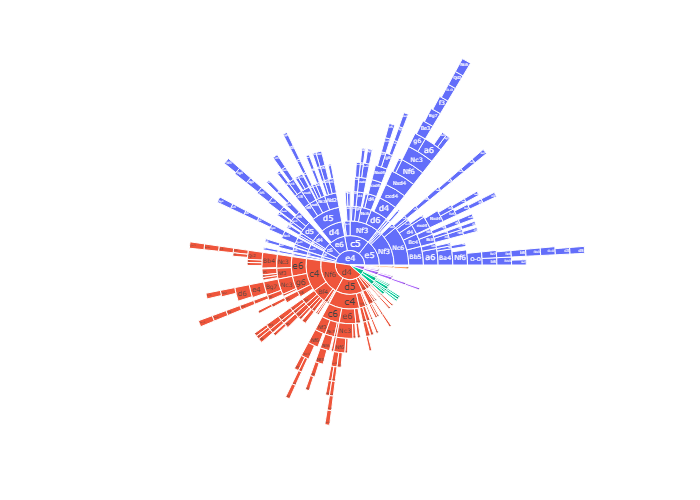

### Awards

Because winning isn’t everything; it’s the only thing :)

See the footnote for further details on selected awards.[^7]

| Award | Description | Winner | Details | Honourable mentions |
| --- | --- | --- | --- | --- |
| x | Archbishop of Accuracy | s2004k1993 | 20.5 ACPL over 242 moves | ihideonbush, david252525 |
| x | Awesome Alt | mn8 | Played for 5 different teams | asn8745, GogoYubari, HicSuntDracones (4) |
| x | Bullet Boss | yellowtides | 17 moves | Axp156, FiveKnights |
| x | David Award | toni4127 | Opponents' record: 21.5/31 | GogoYubari, ethanpowell |
| x | Egalitarian Award | Means to Anand | SD: 91.8 |  |
| x | Gambit Guru | rederik79 | 50% from 2 games | NA |
| x | Giri Award | FollowTheWhiteRabbit, itakeback | 4 draws |  |
| x | Grischuk's Cousin | HoudinicisMedicis | Had 14m 38s left after 10 moves | SycoraxCirce, HighonPotnuse |
| x | Houdini Award | Litzr |  | DMSA_OR, postit |
| x | Intimate with Increment | HoudinicisMedicis | 31.6% | jivey, izzie26 |

[output cut: 10 more lines]

### Detailed statistics

All the following tables are sortable and searchable.

#### Team statistics

| rank | Team | games | points | pts_nonforf | wins | draws | losses | players | avg_moves | ACPL | blunder_pc |
| --- | --- | --- | --- | --- | --- | --- | --- | --- | --- | --- | --- |
| 1 | Hey Guys, it's John | 46 | 33 | 31 | 27 | 8 | 11 | 10 | 39.4782608695652 | 49.0600220264317 | 4.24008810572687 |
| 2 | Ha, We Got Lovlas | 46 | 29 | 26.5 | 24 | 5 | 17 | 8 | 37.9782608695652 | 44.7704636519748 | 3.83514596451059 |
| 3 | Six Piece Tablebase | 44 | 29.5 | 27.5 | 24 | 7 | 13 | 10 | 44.7272727272727 | 41.8973577235772 | 3.2520325203252 |
| 4 | KEEP CALM AND CHESS | 45 | 26.5 | 24 | 20 | 8 | 17 | 12 | 39.0888888888889 | 41.8283115406481 | 2.78567367822626 |
| 5 | YOU SHALL NOT en PASSant! | 44 | 27 | 23.5 | 22 | 3 | 19 | 6 | 38.8863636363636 | 46.3711279953244 | 3.7989479836353 |
| 6 | Caro-Kann of Worms | 45 | 27 | 26 | 21 | 10 | 14 | 9 | 42.5333333333333 | 41.9373040752351 | 3.44827586206897 |
| 7 | Karpov Diem | 38 | 26.5 | 21 | 19 | 4 | 15 | 7 | 38.0789473684211 | 41.8099516240498 | 2.69523151347616 |
| 8 | Flirty Daggers | 47 | 26 | 25 | 23 | 4 | 20 | 9 | 42.4893617021277 | 44.4261392088132 | 4.10615923885829 |
| 9 | Head Hunters | 44 | 26 | 24 | 21 | 6 | 17 | 11 | 38.9318181818182 | 44.7256275539988 | 3.85288966725044 |
| 10 | The RO-Okies | 42 | 25.5 | 21 | 16 | 10 | 16 | 8 | 40.8095238095238 | 42.2042007001167 | 4.3757292882147 |

[output cut: 20 more lines]

#### Best performances / highest accuracy

##### Best relative perfs

Shows players’ *relative* performance ratings: season performance rating minus initial rating.[^8]

*Includes all players with a positive relative performance rating over at least five games.*

| # | Player | Games | W | D | L | Initial | Perf | Diff. |
| --- | --- | --- | --- | --- | --- | --- | --- | --- |
| 1 | PublicRadio | 5 | 5 | 0 | 0 | 1920 | 2759.8 | 839.8 |
| 2 | DMSA_OR | 7 | 7 | 0 | 0 | 1611 | 2357.28571428571 | 746.285714285714 |
| 3 | ihideonbush | 6 | 6 | 0 | 0 | 2168 | 2893.83333333333 | 725.833333333333 |
| 4 | Tim_Nice_But_Dim | 6 | 5 | 1 | 0 | 1430 | 1956.66666666667 | 526.666666666667 |
| 5 | k-night-moves | 8 | 7 | 1 | 0 | 1779 | 2204.125 | 425.125 |
| 6 | mn8 | 7 | 6 | 1 | 0 | 2224 | 2611.42857142857 | 387.428571428572 |
| 7 | saxi90 | 5 | 4 | 1 | 0 | 1743 | 2102.2 | 359.2 |
| 8 | Chaskar | 5 | 4 | 1 | 0 | 1959 | 2301 | 342 |
| 9 | colwem | 8 | 7 | 0 | 1 | 1699 | 2036.75 | 337.75 |
| 10 | Brundd | 7 | 5 | 2 | 0 | 1682 | 1977.71428571429 | 295.714285714286 |

[output cut: 65 more lines]

##### Lowest ACPL

*Includes the 100 players with the lowest ACPL (min. 100 moves played).*

| Rank | Player | Moves | ACPL |
| --- | --- | --- | --- |
| 1 | s2004k1993 | 242 | 20.5 |
| 2 | ihideonbush | 230 | 20.704347826087 |
| 3 | david252525 | 143 | 21.0489510489511 |
| 4 | Grizzzly1000 | 121 | 22.1322314049587 |
| 5 | mn8 | 258 | 24.8837209302326 |
| 6 | Chaskar | 224 | 25.46875 |
| 7 | eie24 | 336 | 26.4553571428571 |
| 8 | yellowtides | 267 | 26.4756554307116 |
| 9 | jg777 | 249 | 27.0481927710843 |
| 10 | mikewhitekl | 221 | 27.1131221719457 |

[output cut: 90 more lines]

#### Time spent / strongest opponents

##### Time spent

*Includes the 50 players who spent the most clock time over the season.*

| Rank | Player | Games | Total time spent |
| --- | --- | --- | --- |
| 1 | Footpath | 8 | 9h 40m 24s |
| 2 | Axp156 | 8 | 9h 12m 25s |
| 3 | cameronbird | 8 | 9h 6m 6s |
| 4 | camcam52 | 8 | 9h 3m 59s |
| 5 | Grzybozbur | 8 | 9h 2m 9s |
| 6 | garfield1980 | 8 | 8h 59m 24s |
| 7 | sgis | 8 | 8h 56m 11s |
| 8 | pepepibote | 8 | 8h 56m 7s |
| 9 | Drotciv | 8 | 8h 56m 6s |
| 10 | Tranzoo | 8 | 8h 54m 12s |

[output cut: 40 more lines]

##### Time spent per move (after move 10)

*Includes everyone who played at least three games.*

| Rank | Player | Games | Moves | Time spent per move | Percentile |
| --- | --- | --- | --- | --- | --- |
| 1 | mmei88 | 3 | 56 | 2m 34.7s | 100 |
| 2 | dlgabriel | 4 | 52 | 2m 33.0s | 99 |
| 3 | InfernalJumble | 8 | 202 | 2m 19.8s | 98 |
| 4 | LarsenB | 7 | 169 | 2m 16.1s | 97 |
| 5 | arbisto | 7 | 166 | 2m 11.6s | 96 |
| 6 | theme | 6 | 188 | 2m 2.7s | 95 |
| 7 | Rolihlahla | 7 | 170 | 2m 1.9s | 94 |
| 8 | badplayer_CM | 7 | 176 | 2m 0.9s | 93 |
| 9 | shetoo | 7 | 201 | 2m 0.4s | 92 |
| 10 | mdaw | 6 | 146 | 1m 59.4s | 91 |

[output cut: 170 more lines]

##### Strength of schedule

These players faced the most in-form opponents across the season, when judged by their opponents’ collective score in all their other games.[^9]

*Includes all players who faced a collective group of opponents that played at least 15 (other) games across the season with a collective score above 50 per cent.*

| # | Player | Opp Games | Opp Pts | Opp % |
| --- | --- | --- | --- | --- |
| 1 | toni4127 | 31 | 21.5 | 69.3548387096774 |
| 2 | GogoYubari | 26 | 18 | 69.2307692307692 |
| 3 | ethanpowell | 40 | 27.5 | 68.75 |
| 4 | areeckx | 25 | 17 | 68 |
| 4 | pioki | 25 | 17 | 68 |
| 5 | Forhavu | 39 | 26.5 | 67.948717948718 |
| 6 | mn8 | 29 | 19.5 | 67.2413793103448 |
| 7 | yellowtides | 36 | 24 | 66.6666666666667 |
| 8 | Chuck_AOE | 22 | 14.5 | 65.9090909090909 |
| 9 | Dodeka | 38 | 25 | 65.7894736842105 |

[output cut: 75 more lines]

#### Comebacks and upsets

##### Comebacks

*Includes players with a positive average “comeback margin” that played at least three games.*[^10]

| Rank | Player | Average Comeback Margin | Total Comeback Margin |
| --- | --- | --- | --- |
| 1 | Litzr | 1.14639861950729 | 9.17118895605831 |
| 2 | DMSA_OR | 1.12678820278806 | 9.01430562230452 |
| 3 | postit | 0.982709153880185 | 8.84438238492167 |
| 4 | colwem | 1.08779859893397 | 8.70238879147177 |
| 5 | k-night-moves | 1.03469860597041 | 8.2775888477633 |
| 6 | JonathanCoffin | 0.976951206423215 | 7.81560965138572 |
| 7 | pkjamoo | 0.94251624983167 | 7.54012999865336 |
| 8 | Tim_Nice_But_Dim | 1.25471157673976 | 7.52826946043856 |
| 9 | lovlas | 1.05339590360002 | 7.37377132520016 |
| 10 | Tranzoo | 0.914322658331972 | 7.31458126665577 |

[output cut: 167 more lines]

##### Biggest upsets

*Includes all players who defeated an opponent rated at least 50 points higher.*

| Rank | Player | Upset Margin |
| --- | --- | --- |
| 1 | theme | 253 |
| 2 | mn8 | 250 |
| 3 | HoudinicisMedicis | 234 |
| 4 | areeckx | 180 |
| 5 | Tim_Nice_But_Dim | 166 |
| 6 | PublicRadio | 162 |
| 7 | JMcrath | 155 |
| 8 | dlgabriel | 130 |
| 9 | Dodeka | 128 |
| 10 | mixxanber | 124 |

[output cut: 57 more lines]

##### Repeated upsets

Includes players who achieved multiple wins over opponents rated at least 50 points higher.

| Rank | Player | Total Upset Margin | Upsets | Avg Upset Margin | Biggest Margin |
| --- | --- | --- | --- | --- | --- |
| 1 | Tim_Nice_But_Dim | 304 | 3 | 101.333333333333 | 166 |
| 2 | Dodeka | 184 | 2 | 92 | 128 |
| 3 | Scarff | 179 | 2 | 89.5 | 109 |
| 4 | Dimesocket | 165 | 2 | 82.5 | 93 |
| 5 | shetoo | 157 | 2 | 78.5 | 89 |
| 6 | maxivgc | 139 | 2 | 69.5 | 80 |
| 7 | ethanpowell | 129 | 2 | 64.5 | 65 |
| 8 | SycoraxCirce | 100 | 2 | 50 | 50 |

#### Dawdlers and instant movers

##### Least time left after move 10

The players with the least time left after 10 moves…who still managed to win![^11]

| Rank | Player | Time left after 10 moves | Link |
| --- | --- | --- | --- |
| 1 | HoudinicisMedicis | 14m 38s | https://lichess.org/O7sOM1ss#19 |
| 2 | SycoraxCirce | 15m 2s | https://lichess.org/szU07vSy#19 |
| 3 | HighonPotnuse | 19m 20s | https://lichess.org/AmPYZ2N6#19 |
| 3 | Kraaft | 19m 20s | https://lichess.org/6iiosUag#20 |
| 4 | Assassin_in_White | 22m 41s | https://lichess.org/AJXGwkpe#20 |
| 5 | Scrooge | 25m 57s | https://lichess.org/UnpsAAza#19 |
| 6 | Scrooge | 26m 57s | https://lichess.org/E9KCZpZc#20 |
| 7 | pepepibote | 27m 1s | https://lichess.org/FUOkejJ2#19 |
| 8 | ethanpowell | 27m 57s | https://lichess.org/hIEQBUFM#19 |
| 9 | FilP | 28m 9s | https://lichess.org/kChoLqAX#19 |

##### Instant moves

Players who made the most ‘instant’ moves over the season, taking less than 0.5 seconds (includes premoves).

*Includes players with more than five ‘instant’ moves.*

| Rank | Player | Instant moves |
| --- | --- | --- |
| 1 | yellowtides | 17 |
| 2 | Axp156 | 15 |
| 3 | FiveKnights | 14 |
| 4 | FlokiTheCat | 13 |
| 4 | kevban | 13 |
| 4 | lovlas | 13 |
| 4 | Showboater | 13 |
| 4 | wookash_888 | 13 |
| 5 | Assassin_in_White | 12 |
| 5 | ChessPatzerFrance | 12 |

[output cut: 37 more lines]

#### Longest thinks, time trouble addicts, and lucky escapes

##### Longest thinks

The longest times spent on a single move.

*Top 100 shown.*

| # | Player | Time spent | Colour | Move | Link |
| --- | --- | --- | --- | --- | --- |
| 1 | checkmonk | 24m 8s | White | 10 | https://lichess.org/GrbUBXvR#19 |
| 2 | theme | 23m 58s | Black | 22 | https://lichess.org/SNrFioJt#44 |
| 3 | Skims | 22m 9s | White | 12 | https://lichess.org/rVcjLMJI#23 |
| 4 | bufferunderrun | 21m 46s | White | 13 | https://lichess.org/7pKJIWjF#25 |
| 5 | eie24 | 21m 1s | White | 23 | https://lichess.org/FyIfDhBc#45 |
| 6 | ChessPatzerFrance | 20m 32s | Black | 27 | https://lichess.org/inbHw2D0#54 |
| 7 | s2004k1993 | 19m 45s | White | 17 | https://lichess.org/RxUx8Wqi#33 |
| 8 | InfernalJumble | 19m 18s | Black | 19 | https://lichess.org/0Vojd4EU#38 |
| 9 | s2004k1993 | 19m 2s | White | 14 | https://lichess.org/5qS0Joyq#27 |
| 10 | InfernalJumble | 18m 48s | White | 15 | https://lichess.org/dyWGwrVs#29 |

[output cut: 90 more lines]

##### Time trouble addicts

Shows players by proportion of moves made in time trouble (defined as having less than a minute remaining on the clock).

*Includes everyone who played at least 100 moves over the season while making at least one move in time trouble.*

| # | Player | All moves | With < 1min left | Time Trouble % |
| --- | --- | --- | --- | --- |
| 1 | HoudinicisMedicis | 244 | 77 | 0.315573770491803 |
| 2 | jivey | 217 | 51 | 0.235023041474654 |
| 3 | izzie26 | 242 | 50 | 0.206611570247934 |
| 4 | michaeltallovsky | 202 | 38 | 0.188118811881188 |
| 5 | revoof | 277 | 42 | 0.151624548736462 |
| 6 | InfernalJumble | 278 | 41 | 0.147482014388489 |
| 7 | makeareason | 188 | 26 | 0.138297872340426 |
| 8 | k-night-moves | 291 | 40 | 0.13745704467354 |
| 9 | s2004k1993 | 240 | 31 | 0.129166666666667 |
| 10 | Kraaft | 228 | 29 | 0.12719298245614 |

[output cut: 56 more lines]

##### Saved by the bell

Players who made moves with under 5 seconds left on their clock…and still won![^12]

| Player | Moves with under 5s left | Least time left | Link |
| --- | --- | --- | --- |
| k-night-moves | 5 | 2 | https://lichess.org/ldeBLYGr |
| jivey | 2 | 4 | https://lichess.org/g1u8Pvce |
| HoudinicisMedicis | 1 | 2 | https://lichess.org/AK1CTVm6 |
| s2004k1993 | 1 | 3 | https://lichess.org/pt8BhyqR |
| Grzybozbur | 1 | 4 | https://lichess.org/TUBNbwRJ |
| s2004k1993 | 1 | 4 | https://lichess.org/5qS0Joyq |

#### Misc. facts

##### Lesser spotted mates

A pawn gave checkmate in 3 games: https://lichess.org/kEhXwkv3, https://lichess.org/9nyvVHed, https://lichess.org/0Ojjmutl.

A knight gave checkmate in 3 games: https://lichess.org/C4wTctTB, https://lichess.org/DhSDMEtr, https://lichess.org/TB6WCrmW.

##### Promotions

81 games had at least one promotion. 4 of these saw an under-promotion.

The most promotions seen in a game was 3: https://lichess.org/agWzcsRI, https://lichess.org/sIxSC268, https://lichess.org/sECT1WnM

##### Rollercoaster games

47 games featured significant winning chances for both sides (as identified by Lichess’s server analysis), comprising 7.4% of all games played.

##### Checks and captures

- Most consecutive checks: 12 (https://lichess.org/1UyNSq7L, https://lichess.org/6TMyP4n0)
- Most consecutive captures: 9 (https://lichess.org/ArEOOLIa, https://lichess.org/hLYDn4JX, https://lichess.org/naIOgElN, https://lichess.org/T9dl4wE3)
- Latest-occurring first capture: ply 34 in https://lichess.org/jZWyQUXr

### About this report

- This report was compiled on 16 August 2021.
- These statistics are presented for general interest only. They are not guaranteed to be comprehensive, complete[^13], accurate, or up to date. They may be periodically revised to incorporate updates and bugfixes.
- Any player determined by Lichess to have violated their Terms of Service when this report was compiled should not appear in the detailed statistics.[^14]
- [Homepage](https://rahulan-c.github.io/lichess4545-stats/) / [source code](https://github.com/rahulan-c/lichess4545-stats)
- Acknowledgements: [Noun Project](https://thenounproject.com/) for the award icons; [Simon Ilincev](https://simonilincev.com/) for chess_graph, which produces the openings sunburst plots.
[^1]: The forfeit rate is the percentage of pairings that didn’t result in a game being played.
[^2]: The number of games played in this statistic can differ from the number of games played in the season, as it excludes games where the result of the pairing was later changed to a forfeit win or loss.
[^3]: The performance ratings in this table only take into account games played on the relevant board, which is why they differ from (and should be preferred to) the ratings given by the board standings tables on the Lichess4545 website.
[^4]: A game’s total clock time is the sum of both players’ move times from move 2 onwards.
[^5]: Currently, gambit openings are identified by the presence of the term *gambit* in the opening name assigned by Lichess. This is admittedly an imperfect approach as it excludes certain openings that should also be considered as gambits such as the Marshall Attack.
[^6]: Qualifying “gambiteers” are ordered by number of gambit games played before percentage score.
[^7]: *Archbishop of Accuracy*: lowest average centipawn loss (ACPL) over all moves played, as determined by Lichess’s server analysis. Minimum 100 moves played. *David Award*: the player whose opponents achieved the highest percentage score across the season, excluding games against the player. One’s opponents must have played over 20 games (against others) to qualify. Suggested by Tranzoo. *Egalitarian Award*: intended for the team whose players performed most similarly to each other. First, I compute all players’ *relative* performance ratings – the difference between their actual performance rating (using FIDE’s method) and their initial rating. Then I group all players by team, and give the award to the team with the lowest standard deviation across its players’ relative ratings. Suggested by Silkthewanderer. *Gambit Guru*: most gambits played while scoring above 50%. *MVP Award*: minimum 5 games played. *Rookie Award*: minimum 4 games played. *Saved by the Bell*: Excludes moves made in positions with an evaluation of under +300 centipawns from the mover’s perspective. Ordering is determined first by # moves played with under 5 seconds remaining, then by least time remaining in such conditions, then by worst eval faced. *Slingshot Specialist*: the player with the highest total rating gap between their opponents and themselves when only considering wins against opponents rated at least 50 rating points higher.︎
[^8]: The season performance ratings presented in this report may differ slightly from the figures given by the Lichess4545 website. Both figures are based on FIDE’s preferred calculation method and exclude unplayed games (such as forfeit wins/losses and scheduling draws.
[^9]: Both the statistic and the name of its associated award – the David Award – were suggested by **Tranzoo**.
[^10]: Originally suggested by **Lou-E**. This table shows players ranked by the size and number of comebacks achieved over the course of the season. For this purpose, the size of a comeback has been defined as the difference between a player’s final score in a game (0, 0.5, or 1) and the worst evaluation during the game that they faced (which is then converted into a rough win probability for their opponent). For example, if I were to win a game after Lichess’s server analysis gave my opponent a 75% chance of winning in a certain position, then I would have earned 1.75 comeback “points” from the game. My opponent of course would have earned zero points. If the game had been drawn, I would have instead earned only 0.75 comeback “points”.
[^11]: Statistic suggested by **Silkthewanderer**.
[^12]: Excludes moves made in technically winning positions, defined as $\tt eval \le 300$ (from the mover’s perspective). Players are first ordered by number of moves made with 5 seconds or fewer remaining, then by least time remaining in such conditions, and finally by worst eval faced.
[^13]: For example, this report excludes from its analysis all games of less than 5 plies (half-moves), games that ended in a disconnection or by “cheat detected”, games that were aborted, and games that started from a custom position.
[^14]: However, players who were banned from the Lichess4545 leagues after finishing a season in the top three places are still shown with a podium place in that season’s report.